# T Tests Tutorial

Simon Hans Edasi

5/18/2023

## Section 5.3 Two sample t-test (Student’s t-test)

Create the script.

```r
# Clear the memory.
rm(list = ls())




# Load libraries ggplot2, dpylr, readr
library(ggplot2)
library(dplyr)
library(readr)
```

Load the data set “ozone.csv” and assign it to an object named “ozone”.

First, some information about the experiment.

We will analyze ozone levels in gardens distributed around a city. The gardens were either to the west of the city center or to the east. The data are ozone concentrations in parts per hundred million (pphm). Ozone in excess of 8 pphm can damage lettuce plants-they bolt and get filled with latex and are yucky to eat. We are interested in whether there is a difference in the average ozone concentration between gardens in the east and the west.

```r
ozone <- read.csv('ozone.csv')
```

Check the data set using “View()”.  
NOTE: The “V” is capitalized. This is the raw data. We will go on to summarize the data.

Display the names used in the data set using “names()”.

```r
# View(ozone)




 # Look at a horizontal view of the data
 # using "glimpse()".

glimpse(ozone)
```

```
## Rows: 20
## Columns: 3
## $ Ozone           <dbl> 61.7, 64.0, 72.4, 56.8, 52.4, 44.8, 70.4, 67.6, 68.8, …
## $ Garden.location <chr> "West", "West", "West", "West", "West", "West", "West"…
## $ Garden.ID       <chr> "G1", "G2", "G3", "G4", "G5", "G6", "G7", "G8", "G9", …
```

Plot the data for exploration of the central tendency of the data from the two gardens using a histogram.

We thus accomplish the process of visualizing our hypothesis and evaluating some assumptions of a two-sample t-test, all in one script.

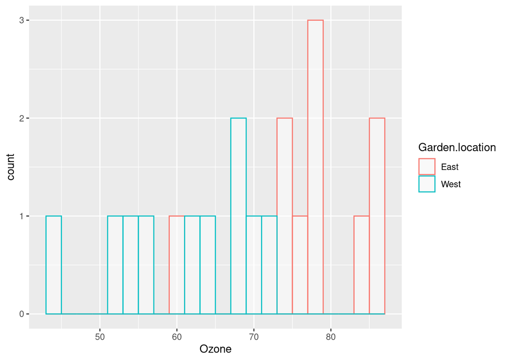

```r
ggplot(ozone, aes(x=Ozone, color=Garden.location)) +
  geom_histogram(fill="white", alpha=0.5, position="identity", bins = 10, binwidth = 2)
```

### A digression into outlier detection and box plots of data.

Plot the data for further exploration for outliers, errors, etc. using a box plot.

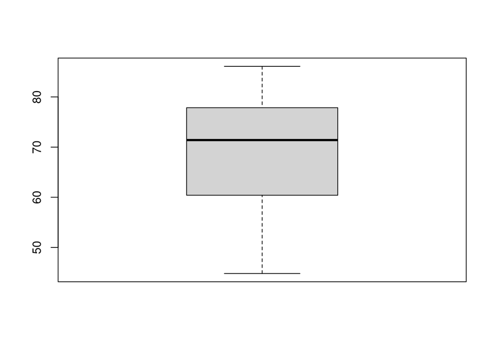

```r
boxplot(ozone$Ozone)
```

Perform an analysis/checking, then plot the data.

Create code to detect outliers and label them on the box plot using a created function, “is_outlier(x)”.

The results are plotted. The text values are plotted via geom_text and an aesthetic label equal to our new variable, outlier. The text for the outlier is offset a small amount to the right using hjust = -0.3, so that the values are next to rather than on top of the outlier points themselves.

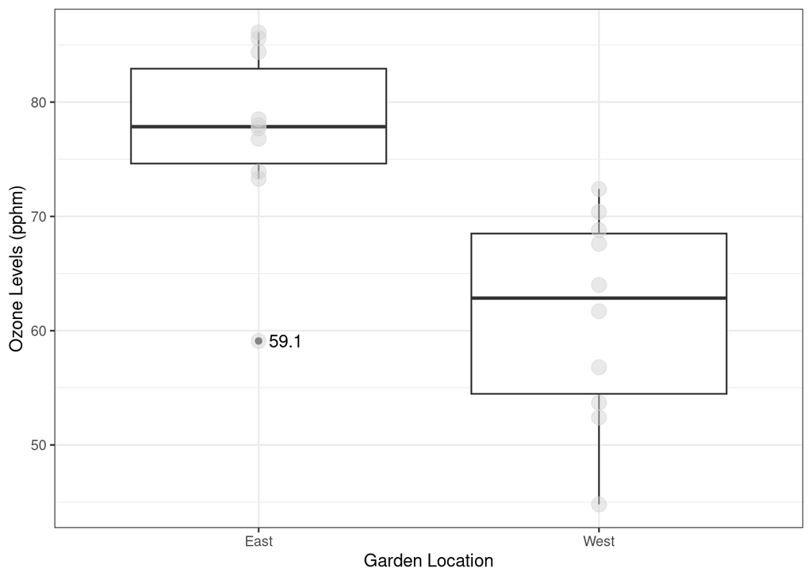

```r
is_outlier <- function(x) {
  return(x < quantile(x,0.25) - 1.5 * IQR(x) |
           x > quantile(x, 0.73) + 1.5 * IQR(x))
}
ozone %>%
  group_by(Garden.location) %>%
  mutate(outlier = ifelse(is_outlier(Ozone), Ozone, as.numeric(NA))) %>%
  ggplot(., aes(x = factor(Garden.location), y = Ozone)) +
  geom_boxplot() +
  geom_text(aes(label = outlier), na.rm = TRUE, hjust = -0.3)+
  geom_point(size = 4, colour = 'lightgrey', alpha = 0.5) +
  xlab("Garden Location") +
  ylab("Ozone Levels (pphm)") +
  theme_bw()
```

To explore this outlier detection function, we will look at a built-in R data set, “mtcars”, that is known to have outliers.

Load needed libraries (dplyr and ggplot2)

```r
# Get list of built-in R data sets.
library(dplyr)
library(ggplot2)


# Get the "mtcars" built-in data set.
data(mtcars)



# View the data.
mtcars
```

```
##                      mpg cyl  disp  hp drat    wt  qsec vs am gear carb
## Mazda RX4           21.0   6 160.0 110 3.90 2.620 16.46  0  1    4    4
## Mazda RX4 Wag       21.0   6 160.0 110 3.90 2.875 17.02  0  1    4    4
## Datsun 710          22.8   4 108.0  93 3.85 2.320 18.61  1  1    4    1
## Hornet 4 Drive      21.4   6 258.0 110 3.08 3.215 19.44  1  0    3    1
## Hornet Sportabout   18.7   8 360.0 175 3.15 3.440 17.02  0  0    3    2
## Valiant             18.1   6 225.0 105 2.76 3.460 20.22  1  0    3    1
## Duster 360          14.3   8 360.0 245 3.21 3.570 15.84  0  0    3    4
## Merc 240D           24.4   4 146.7  62 3.69 3.190 20.00  1  0    4    2
## Merc 230            22.8   4 140.8  95 3.92 3.150 22.90  1  0    4    2
## Merc 280            19.2   6 167.6 123 3.92 3.440 18.30  1  0    4    4
## Merc 280C           17.8   6 167.6 123 3.92 3.440 18.90  1  0    4    4
## Merc 450SE          16.4   8 275.8 180 3.07 4.070 17.40  0  0    3    3
## Merc 450SL          17.3   8 275.8 180 3.07 3.730 17.60  0  0    3    3
## Merc 450SLC         15.2   8 275.8 180 3.07 3.780 18.00  0  0    3    3
## Cadillac Fleetwood  10.4   8 472.0 205 2.93 5.250 17.98  0  0    3    4
## Lincoln Continental 10.4   8 460.0 215 3.00 5.424 17.82  0  0    3    4
## Chrysler Imperial   14.7   8 440.0 230 3.23 5.345 17.42  0  0    3    4
## Fiat 128            32.4   4  78.7  66 4.08 2.200 19.47  1  1    4    1
## Honda Civic         30.4   4  75.7  52 4.93 1.615 18.52  1  1    4    2
## Toyota Corolla      33.9   4  71.1  65 4.22 1.835 19.90  1  1    4    1
## Toyota Corona       21.5   4 120.1  97 3.70 2.465 20.01  1  0    3    1
## Dodge Challenger    15.5   8 318.0 150 2.76 3.520 16.87  0  0    3    2
## AMC Javelin         15.2   8 304.0 150 3.15 3.435 17.30  0  0    3    2
## Camaro Z28          13.3   8 350.0 245 3.73 3.840 15.41  0  0    3    4
## Pontiac Firebird    19.2   8 400.0 175 3.08 3.845 17.05  0  0    3    2
## Fiat X1-9           27.3   4  79.0  66 4.08 1.935 18.90  1  1    4    1
## Porsche 914-2       26.0   4 120.3  91 4.43 2.140 16.70  0  1    5    2
## Lotus Europa        30.4   4  95.1 113 3.77 1.513 16.90  1  1    5    2
## Ford Pantera L      15.8   8 351.0 264 4.22 3.170 14.50  0  1    5    4
## Ferrari Dino        19.7   6 145.0 175 3.62 2.770 15.50  0  1    5    6
## Maserati Bora       15.0   8 301.0 335 3.54 3.570 14.60  0  1    5    8
## Volvo 142E          21.4   4 121.0 109 4.11 2.780 18.60  1  1    4    2
```

Apply the outlier detection function to the “mtcars” data set and plot the data as a box plot.

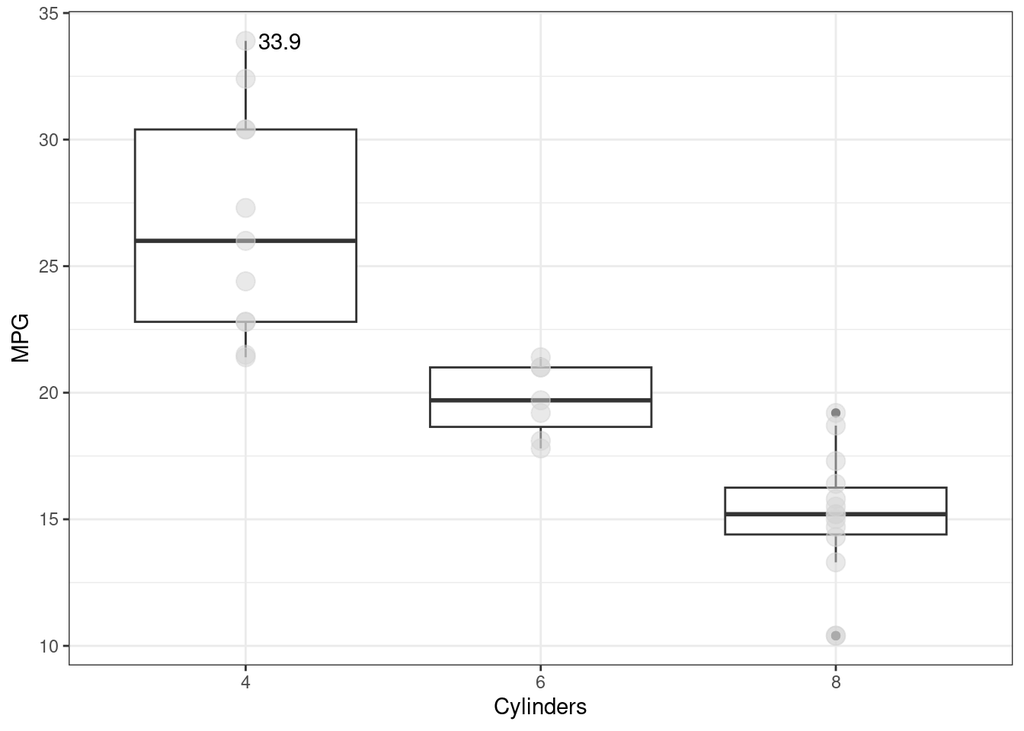

```r
is_outlier <- function(x) {
  return(x < quantile(x,0.25) - 1.5 * IQR(x) |
           x > quantile(x, 0.73) + 1.5 * IQR(x))
}
mtcars %>%
  group_by() %>%
  mutate(outlier = ifelse(is_outlier(mpg), mpg, as.numeric(NA))) %>%
  ggplot(., aes(x = factor(cyl), y = mpg)) +
  geom_boxplot() +
  geom_text(aes(label = outlier), na.rm = TRUE, hjust = -0.3)+
  geom_point(size = 4, colour = 'lightgrey', alpha = 0.5) +
  xlab("Cylinders") +
  ylab("MPG") +
  theme_bw()
```

That is pretty useful in helping us decide what to do with the values identified with our user defined outlier detection function, “is_outlier()”!

```r
# mtcars$outlier <- ifelse(is_outlier(mtcars$mpg), mtcars$mpg, as.numeric(NA))
# print(mtcars, n=nrow(ozone))
```

End of digression on outliers in and box plot creation for exploring data.

### Resume working through Section 5.3: Two sample t-test (Student’s t-test)

Reenter the previous work (from before the digression on outliers). Create the new script.

```r
# Clear the memory.

rm(list = ls())


# Load libraries.
library(ggplot2)
library(dplyr)
library(readr)
```

Load the data set “ozone.csv” and assign it to an object named “ozone”.

First, some information about the experiment.

We will analyse ozone levels in gardens distributed around a city. The gardens were either to the west of the city centre or to the east. The data are ozone concentrations in parts per hundred million (pphm). Ozone in excess of 8 pphm can damage lettuce plants-they bolt and get filled with latex and are yucky to eat. We are interested in whether there is a difference in the average ozone concentration between gardens in the east and the west.

```r
ozone <- read.csv('ozone.csv')
```

Check the data set using “View()”.  
NOTE: The “V” is capitalized. This is the raw data. We will go on to summarize the data.

Display the names used in the data set using “names()”.

```r
names(ozone)
```

```
## [1] "Ozone"           "Garden.location" "Garden.ID"
```

```r
# Look at a horizontal view of the data using "glimpse()".
```

Plot the data for exploration of the central tendency of the data from the two gardens using a histogram.

We thus accomplish the process of visualizing our hypothesis and evaluating some assumptions of a two-sample t-test, all in one script.

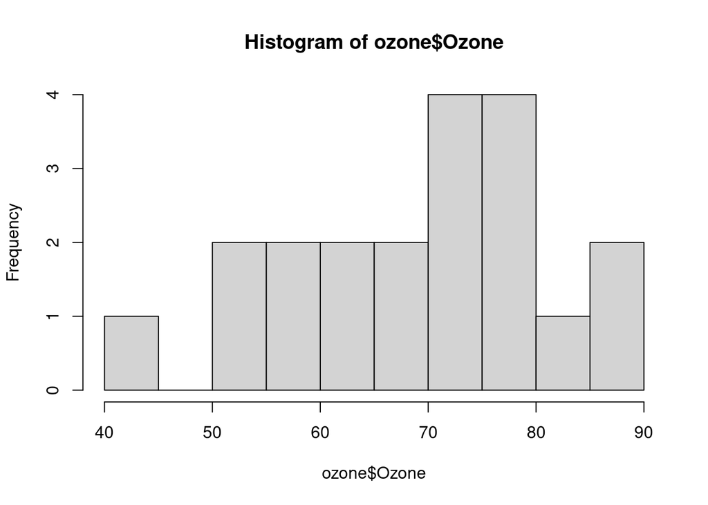

```r
hist(ozone$Ozone)
```

```r
library(glue)
east <- filter(ozone, Garden.location=="East")
east_mean = round(mean(east$Ozone), 3)
east_std_dev = round(sd(east$Ozone), 3)
east_std_err = round(sd(east$Ozone)/sqrt(length(east$Ozone)), 3)




west <- filter(ozone, Garden.location=="West")
west_mean = round(mean(west$Ozone), 3)
west_std_dev = round(sd(west$Ozone), 3)
west_std_err = round(sd(west$Ozone)/sqrt(length(west$Ozone)), 3)


# Display the results for the ozone levels.
glue('East garden mean ozone: {east_mean}, STD: {east_std_dev}, std error: {east_std_err}')
```

```
## East garden mean ozone: 77.34, STD: 7.873, std error: 2.49
```

```r
glue('West garden mean ozone: {west_mean}, STD: {west_std_dev}, std error: {west_std_err}')
```

```
## West garden mean ozone: 61.26, STD: 9.061, std error: 2.865
```

Perform the two-sample t-test. Assume alpha = 0.05.

Test for equality of variances even though the procedure we will use, Welch’s method, relaxes the assumption of equality of variances, we will still test for the validity of that assumption.

The test for equality of variances is an F test.

Get help on “var.test()”.

```r
# Recall what is in the Ozone dataset
```

Perform the equality of variance test.

```r
var.test(east$Ozone, west$Ozone)
```

```
##
##  F test to compare two variances
##
## data:  east$Ozone and west$Ozone
## F = 0.75503, num df = 9, denom df = 9, p-value = 0.6823
## alternative hypothesis: true ratio of variances is not equal to 1
## 95 percent confidence interval:
##  0.1875386 3.0397437
## sample estimates:
## ratio of variances
##          0.7550293
```

Check the normality assumption by generating a Q-Q Plot.

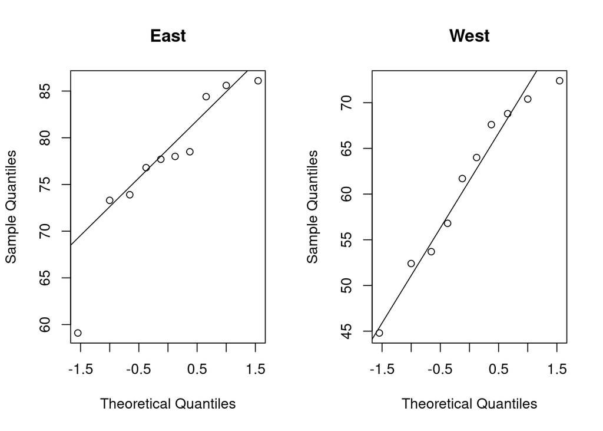

```r
par(mfrow = c(1,2))
qqnorm(east$Ozone, main = 'East')
qqline(east$Ozone)

qqnorm(west$Ozone, main = 'West')
qqline(west$Ozone)
```

Do Q-Q Plots for East and West garden locations separately.

We will plot these side-by-side using the R base “par()” function. This will give us a plotting window that consists of one row and two columns.

Do Q-Q Plot for all of the data regardless of garden location.

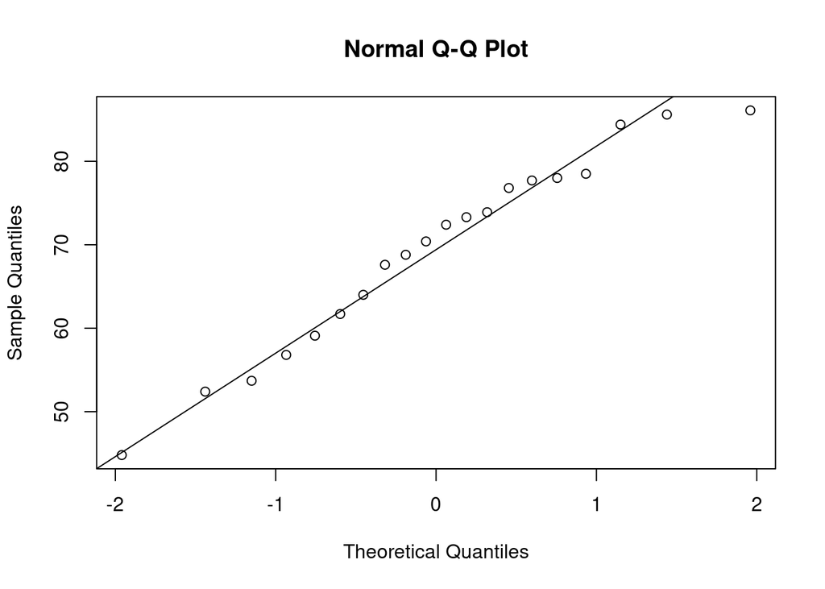

```r
qqnorm(ozone$Ozone)
qqline(ozone$Ozone)
```

Do Q-Q Plot using “ggplot” and its functions.

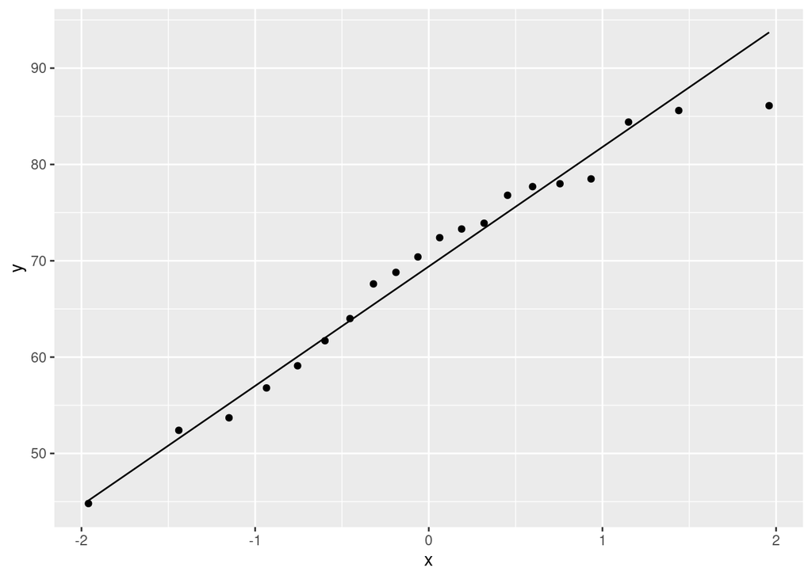

```r
ggplot(ozone, aes(sample = Ozone)) +
  stat_qq() +
  stat_qq_line()
```

```r
# ozone
```

We are going to perform a two sample t-test where the null hypothesis is that the means are equal and the alternative is that theya are not equal.

First, read the help file on a two sample t-test.

```r
?t.test()
```

Select the alpha value and calculate the degrees of freedom. This is a two tailed test, so we put alpha/2 in each tail.

```r
alpha = 0.05
dof = nrow(east) + nrow(west) - 2
```

Display this in another way.

This is a two tailed test, so we put alpha/2 in each tail.

The resulting positive critical value is found as (getting the positive critical value is the reason for the 1-(alpha/2) rather than using alpha/2).

```r
print(Critical_Value <- qt(1-(alpha/2),dof))
```

```
## [1] 2.100922
```

Display the critical value in another way.

```r
t.test(east$Ozone, west$Ozone, var.equal = TRUE, conf.level = 1-alpha)
```

```
##
##  Two Sample t-test
##
## data:  east$Ozone and west$Ozone
## t = 4.2363, df = 18, p-value = 0.0004966
## alternative hypothesis: true difference in means is not equal to 0
## 95 percent confidence interval:
##   8.105323 24.054677
## sample estimates:
## mean of x mean of y
##     77.34     61.26
```

```r
t.test(east$Ozone, west$Ozone, var.equal = FALSE, conf.level = 1-alpha)
```

```
##
##  Welch Two Sample t-test
##
## data:  east$Ozone and west$Ozone
## t = 4.2363, df = 17.656, p-value = 0.0005159
## alternative hypothesis: true difference in means is not equal to 0
## 95 percent confidence interval:
##   8.094171 24.065829
## sample estimates:
## mean of x mean of y
##     77.34     61.26
```

Interpretation of output from BC&P.

Let us spend a bit of time reviewing the output as a way to reinforce aspects of our workflow. We will call this the anatomy of the R output:

[1] The first line of the output tells us the statistical test performed: a Welch two-sample t-test. This is what we expected, apart from the word ‘Welch’: this is a clear indication that R is doing something slightly unexpected, and we should not ignore such an alarm bell. We’ll cover this later, however.

[2] Next we see that the data that have been used are declared-this is a good way to confirm that you’ve analyzed the data you wanted to analyze.

[3] The next line provides the traditional t-test test statistic, degrees of freedom, and p-value. We assume you know what these mean.

[4] However, let us use the next few lines of output to make a few clear points about the two sample t-test. The output declares the alternative hypothesis to us: that the true difference in means is not equal to 0. This should help you understand more of what you’ve been doing. If the difference between the two means is 0 then they are the same, and we have no grounds for rejecting the null hypothesis.

[5] Next in the output is a 95% confidence interval. This interval is around the difference between the two means. Keep in mind that the difference would be 0 if the means were the same. The fact that this interval does not include 0 provides an answer to our initial question. We can conclude that they are probably different. This falls in line with the value of the test statistic, the critical value for our chosen alpha level, and associated p-value.

[6] Finally, the output provides the means in each group.

Back to the word ‘Welch’. A quick look in the help files (?t.test) or on Wikipedia reveals that this method is named for the statistician who created it. It allows the assumption of equal variances to be relaxed. While you may have made the effort to assess the assumption of equal variances above, and found the variances relatively similar, you now know that there are options for when this assumption is not met!

## An IMPORTANT NOTE

IT IS ALWAYS ENCUMBENT UPON YOU TO CHECK IF ALL OF THE ASSUMPTIONS OF THE PROCEDURES YOU ARE USING ARE MET BY THE DATA. IF THEY ARE NOT, THEN YOU NEED TO EXPLAIN WHY WHAT YOU ARE DOING IS VALID!

End of the t_Tests Tutorial!!